# Demystifying multichannel Singular Spectral Analysis (mSSA)

### Example 9: What about missing data?

There are a few strategies for missing data. The simplest is to just ignore and let SSA try to find the connective values. That's what we'll do in this example: take a sinusoid, remove some fraction of the data

(One can also place dummy data and use the reconstruction to refine.)

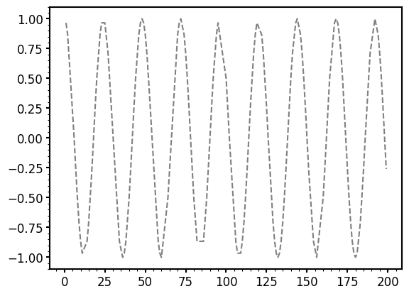

```python
N=200 # set the initial number of data points
R=100 # set the number of data points to remove
ndim=1
testrange = np.arange(0,N,1)
testdata = np.cos(np.arange(0,N,1)*np.pi/12.)

exclude = np.unique(np.random.randint(0,N,R)) # pick samples to remove

R = len(exclude)
data = np.zeros([ndim,N-R])
dtime = np.zeros(N-R)


i = 0
for v in range(0,N):
    if v not in exclude:
        data[0][i] = testdata[v]
        dtime[i] = testrange[v]
        i+=1

plt.plot(dtime,data[0],color='grey',linestyle='dashed')
#plt.plot(testrange,testdata,color='black')
```

```python
# now perform SSA steps

N = len(data[0])

L = 100   # set the window length
K = N-L+1 # calculate the length of the lagged series
Y = embed_data(data,L,K,ndim)
C = make_covariance(Y,K)  # not aware of dimensions
PC,EOF,SV = make_pcs(C,Y) # not aware of dimensions
```

```
Shape of Y: (100, 19)
C shape: (19, 19)
PC shape: (100, 19)
Left singular vector shape: (19, 19)
```

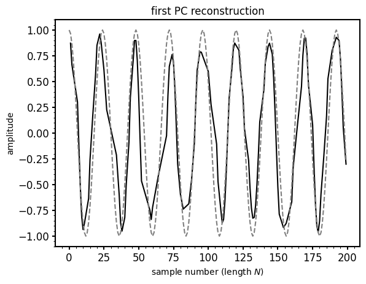

```python
# examine the reconstruction
O = reconstruct(PC,EOF,0,K,0)
O += reconstruct(PC,EOF,1,K,0)

plt.figure()
plt.plot(dtime,O,color='black')
plt.plot(testrange,testdata,color='grey',linestyle='dashed')
plt.title('first PC reconstruction')
plt.xlabel('sample number (length $N$)')
plt.ylabel('amplitude')
```

In the end, we can see that the reconstruction is able to pick up the period quite well, even with a large number of missing data samples!

### Example 10: Nothing from nothing

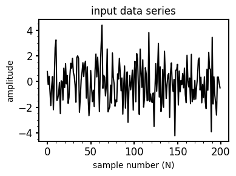

```python
ndim = 1
N = 200
L = 70
K = N-L+1

# set up some gaussian noise
data = np.zeros([ndim,N])
noiselevel = 1.5
data[0] = np.random.normal(0.0,noiselevel,size=data[0].size)

plt.figure(figsize=(4,3),facecolor='white')
plt.plot(data[0],color='black')
plt.title('input data series');plt.ylabel('amplitude');plt.xlabel('sample number (N)')
plt.tight_layout()
```

```
Shape of Y: (70, 131)
C shape: (131, 131)
PC shape: (70, 131)
Left singular vector shape: (131, 131)
```

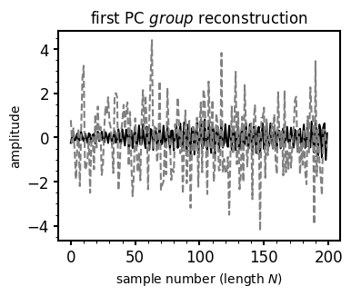

```python
# perform the SSA steps
T = embed_data(data,L,K,1)
C = make_covariance(T,K)
PC,EOF,SV = make_pcs(C,T)
O = reconstruct(PC,EOF,0,K,0)
O += reconstruct(PC,EOF,1,K,0)

plt.figure(figsize=(4,3),facecolor='white')

plt.plot(O,color='black')
plt.plot(data[0],color='grey',linestyle='dashed')
plt.title('first PC $group$ reconstruction')
plt.xlabel('sample number (length $N$)')
plt.ylabel('amplitude')
```

1. The correlation tends to be at very high frequency (higher than any frequency in the system), which outs it as false.
2. When correlating multiple series, it is harder to make a false signal -- because it would have to be common noise in different time series.

But worth being careful!